# Answers to Exercises: Let’s practice more GLMs

## Alternative: effects considered as linear

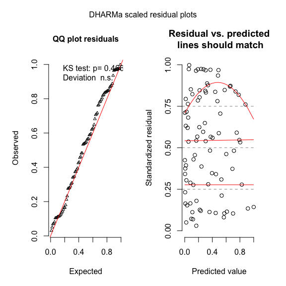

```r
esoph$alc_num <- unclass(esoph$alcgp)
esoph$tob_num <- unclass(esoph$tobgp)
mod_esoph_probit3 <- glm(cbind(ncases, ncontrols) ~ agegp_f + alc_num + tob_num, data = esoph,
                         family = binomial(link = "probit"))
plot(simulateResiduals(mod_esoph_probit3, refit = TRUE, n = 1000))
```

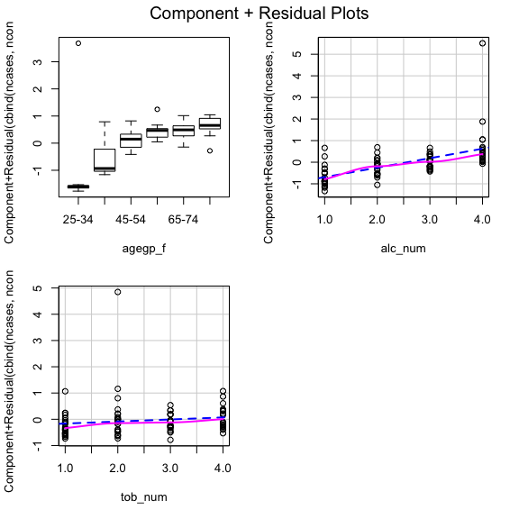

```r
crPlots(mod_esoph_probit3)
```

```r
AIC(mod_esoph_probit)
```

```
## [1] 221.825
```

```r
AIC(mod_esoph_probit2)
```

```
## [1] 234.3696
```

```r
AIC(mod_esoph_probit3)
```

```
## [1] 218.8386
```

```r
confint(mod_esoph_probit3)
```

```
##                    2.5 %     97.5 %
## (Intercept)  -4.66120665 -2.8095856
## agegp_f35-44 -0.03856800  1.8280202
## agegp_f45-54  0.71465265  2.4983633
## agegp_f55-64  0.94248804  2.7131850
## agegp_f65-74  1.14747222  2.9354270
## agegp_f75+    1.02421193  2.9346507
## alc_num       0.29182068  0.4810442
## tob_num       0.06227855  0.2460660
```

This last model seems quite good and it allows to answer our question!

## More?

- One could also do a model with only age and tabaco, one with only age and alcool and compare those by parametric bootstrap to get a p-value. But let us stop here for this exercise.
- One could explore interactions.

# Dataset: carData::TitanicSurvival

## Goal

- Find out who mostly survived and who mostly died during the Titanic disaster of 1912.
- Compute the odds-ratio for survival between the two most contrasting groups of individuals.

## Exploration of the data

```r
data(TitanicSurvival, package = "carData")
```

```r
head(TitanicSurvival)
```

```
##                                 survived    sex     age passengerClass
## Allen, Miss. Elisabeth Walton        yes female 29.0000            1st
## Allison, Master. Hudson Trevor       yes   male  0.9167            1st
## Allison, Miss. Helen Loraine          no female  2.0000            1st
## Allison, Mr. Hudson Joshua Crei       no   male 30.0000            1st
## Allison, Mrs. Hudson J C (Bessi       no female 25.0000            1st
## Anderson, Mr. Harry                  yes   male 48.0000            1st
```

```r
str(TitanicSurvival)
```

```
## 'data.frame':    1309 obs. of  4 variables:
##  $ survived      : Factor w/ 2 levels "no","yes": 2 2 1 1 1 2 2 1 2 1 ...
##  $ sex           : Factor w/ 2 levels "female","male": 1 2 1 2 1 2 1 2 1 2 ...
##  $ age           : num  29 0.917 2 30 25 ...
##  $ passengerClass: Factor w/ 3 levels "1st","2nd","3rd": 1 1 1 1 1 1 1 1 1 1 ...
```

```r
summary(TitanicSurvival)
```

```
##  survived      sex           age          passengerClass
##  no :809   female:466   Min.   : 0.1667   1st:323
##  yes:500   male  :843   1st Qu.:21.0000   2nd:277
##                         Median :28.0000   3rd:709
##                         Mean   :29.8811
##                         3rd Qu.:39.0000
##                         Max.   :80.0000
##                         NA's   :263
```

```r
with(data = TitanicSurvival,
     tapply(survived, sex, function(x) mean(x == "yes")))
```

```
##    female      male
## 0.7274678 0.1909846
```

```r
with(data = TitanicSurvival,
     tapply(survived, passengerClass, function(x) mean(x == "yes")))
```

```
##       1st       2nd       3rd
## 0.6191950 0.4296029 0.2552891
```

```r
with(data = TitanicSurvival, table(sex, passengerClass))
```

```
##         passengerClass
## sex      1st 2nd 3rd
##   female 144 106 216
##   male   179 171 493
```

## Visualization of the data

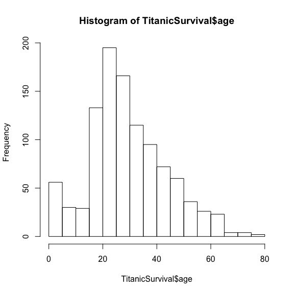

```r
hist(TitanicSurvival$age)
```

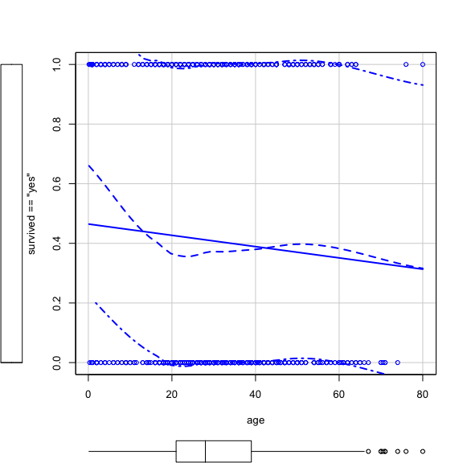

```r
library(car)
scatterplot(survived == "yes" ~ age, data = TitanicSurvival)
```

## We recode some variables

```r
TitanicSurvival$surv <-  TitanicSurvival$survived == "yes"
TitanicSurvival$age_f <- cut(TitanicSurvival$age, breaks = c(0, 10, 25, 35, 50, 81), include.lowest = TRUE)
table(TitanicSurvival$age_f)
```

```
##
##  [0,10] (10,25] (25,35] (35,50] (50,81]
##      86     357     281     227      95
```

## Fitting the models

We fit a serie of models with different links and considering age as factor or continuous:

```r
mod_logit <- glm(surv ~ age_f+passengerClass+sex, data = TitanicSurvival, family = binomial(link = "logit"))
mod_probit <- glm(surv ~ age_f+passengerClass+sex, data = TitanicSurvival, family = binomial(link = "probit"))
mod_cauchit <- glm(surv ~ age_f+passengerClass+sex, data = TitanicSurvival, family = binomial(link = "cauchit"))

mod_logit2 <- glm(surv ~ age+passengerClass+sex, data = TitanicSurvival,
                 family = binomial(link = "logit"))
mod_probit2 <- glm(surv ~ age+passengerClass+sex, data = TitanicSurvival,
                  family = binomial(link = "probit"))
mod_cauchit2 <- glm(surv ~ age+passengerClass+sex, data = TitanicSurvival,
                   family = binomial(link = "cauchit"))

rbind(AIC(mod_logit),
      AIC(mod_probit),
      AIC(mod_cauchit),
      AIC(mod_logit2),
      AIC(mod_probit2),
      AIC(mod_cauchit2))
```

```
##          [,1]
## [1,] 995.0867
## [2,] 997.4459
## [3,] 978.3824
## [4,] 992.4531
## [5,] 994.5528
## [6,] 981.3796
```

## Checking the assumptions

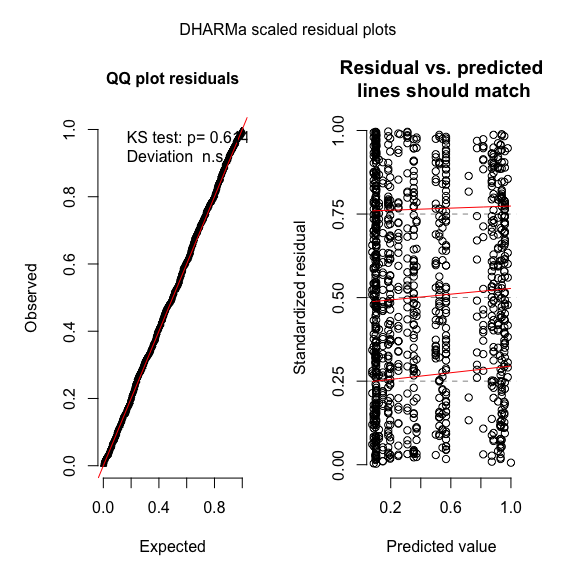

```r
library(DHARMa)
resid_Titanic <- simulateResiduals(mod_cauchit, refit = TRUE, n = 1000)
plot(resid_Titanic)
```

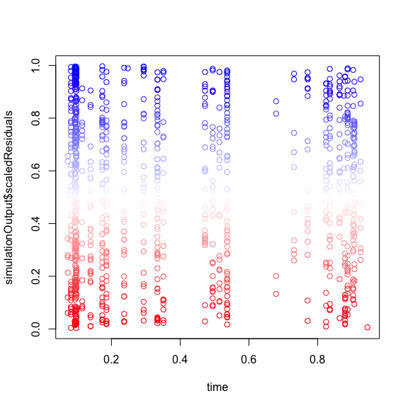

```
##
##  Durbin-Watson test
##
## data:  simulationOutput$scaledResiduals ~ 1
## DW = 1.9828, p-value = 0.3902
## alternative hypothesis: true autocorrelation is greater than 0
```

```r
testTemporalAutocorrelation(resid_Titanic, time = mod_cauchit$fitted.values)
```

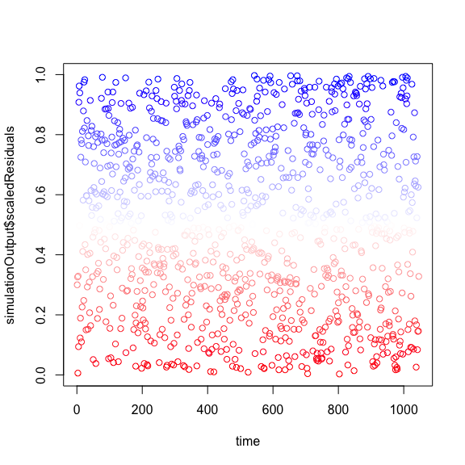

```
##
##  Durbin-Watson test
##
## data:  simulationOutput$scaledResiduals ~ 1
## DW = 1.9914, p-value = 0.4446
## alternative hypothesis: true autocorrelation is greater than 0
```

```r
testTemporalAutocorrelation(resid_Titanic, time = 1:nrow(mod_cauchit$model))
```

```r
testOverdispersion(resid_Titanic)
```

```
##
##  DHARMa nonparametric overdispersion test via comparison to
##  simulation under H0 = fitted model
##
## data:  resid_Titanic
## dispersion = 1.0723, p-value = 0.001
## alternative hypothesis: overdispersion
```

The overdispersion is significant but very small, so we will ignore it!

## We look at predictions

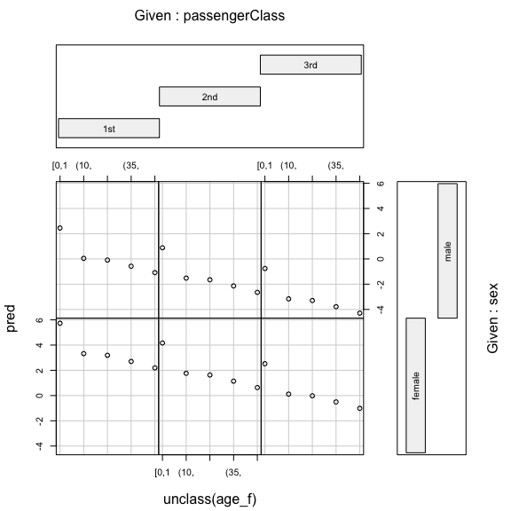

```r
data.for.pred <- with(data = TitanicSurvival,
                 expand.grid(age_f = levels(age_f), passengerClass = levels(passengerClass), sex = levels(sex)))
pred <- predict(mod_cauchit, newdata = data.for.pred, type = "link")
data.to.plot <- cbind(data.for.pred, pred = pred)
coplot(pred ~ unclass(age_f) | passengerClass + sex, data = data.to.plot)
```

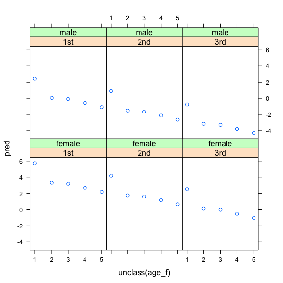

```r
library(lattice) ## same, more fancy
xyplot(pred ~ unclass(age_f) | passengerClass + sex, data = data.to.plot)
```

## GAM?

As the effect of age looks quite linear except for the category in which we have few data we also try a GAM

```r
library(mgcv)
mod_cauchit_gam <- gam(surv ~ s(age) + passengerClass + sex, data = TitanicSurvival, family = binomial(link = "cauchit"))
AIC(mod_cauchit_gam)
```

```
## [1] 972.3109
```

The model is a bit better, we could use it.

## GAM model assumptions:

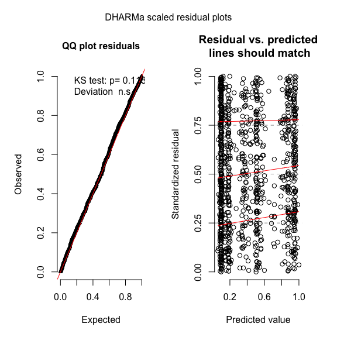

```r
cauchit_gam_resid <- simulateResiduals(mod_cauchit_gam)
plot(cauchit_gam_resid)
```

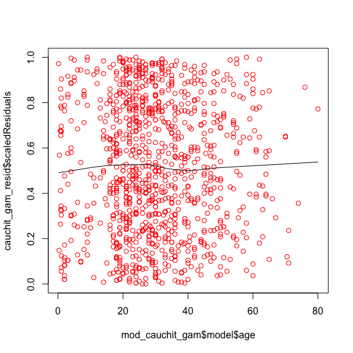

```r
scatter.smooth(mod_cauchit_gam$model$age, cauchit_gam_resid$scaledResiduals, col = 2) ## linearity
```

```r
testOverdispersion(cauchit_gam_resid)
```

```
##
##  DHARMa nonparametric overdispersion test via IQR of scaled
##  residuals against IQR expected under uniform
##
## data:  cauchit_gam_resid
## dispersion = 1.0136, p-value = 0.315
## alternative hypothesis: overdispersion
```

## Tests

```r
Anova(mod_cauchit)
```

```
## Analysis of Deviance Table (Type II tests)
##
## Response: surv
##                LR Chisq Df Pr(>Chisq)
## age_f            37.089  4  1.727e-07 ***
## passengerClass  124.906  2  < 2.2e-16 ***
## sex             292.157  1  < 2.2e-16 ***
## ---
## Signif. codes:  0 '***' 0.001 '**' 0.01 '*' 0.05 '.' 0.1 ' ' 1
```

```r
anova(mod_cauchit_gam)
```

```
##
## Family: binomial
## Link function: cauchit
##
## Formula:
## surv ~ s(age) + passengerClass + sex
##
## Parametric Terms:
##                df Chi.sq  p-value
## passengerClass  2  67.04 2.77e-15
## sex             1  87.49  < 2e-16
##
## Approximate significance of smooth terms:
##          edf Ref.df Chi.sq  p-value
## s(age) 7.488  8.327  38.67 7.33e-06
```

## Predictions

```r
data.for.pred2 <- with(data = TitanicSurvival,
                      expand.grid(age_f = levels(TitanicSurvival$age_f), passengerClass = levels(passengerClass), sex = levels(sex)))
data.for.pred2$age <- NA
data.for.pred2$age[data.for.pred2$age_f == "[0,10]"] <- (10 - 0)/2
data.for.pred2$age[data.for.pred2$age_f == "(10,25]"] <- (25 + 10)/2
data.for.pred2$age[data.for.pred2$age_f == "(25,35]"] <- (25 + 35)/2
data.for.pred2$age[data.for.pred2$age_f == "(35,50]"] <- (35 + 50)/2
data.for.pred2$age[data.for.pred2$age_f == "(50,81]"] <- (50 + 81)/2

pred_age_f <- predict(mod_cauchit, newdata = data.for.pred2, type = "response")
pred_age_gam <- predict(mod_cauchit_gam, newdata = data.for.pred2, type = "response")
data.to.plot2 <- cbind(data.for.pred2, pred_age_f = pred_age_f, pred_age_gam = pred_age_gam)

pred_f_1 <- subset(data.to.plot2, sex == "female" & passengerClass == "1st")
pred_f_2 <- subset(data.to.plot2, sex == "female" & passengerClass == "2nd")
pred_f_3 <- subset(data.to.plot2, sex == "female" & passengerClass == "3rd")

pred_m_1 <- subset(data.to.plot2, sex == "male" & passengerClass == "1st")
pred_m_2 <- subset(data.to.plot2, sex == "male" & passengerClass == "2nd")
pred_m_3 <- subset(data.to.plot2, sex == "male" & passengerClass == "3rd")
```

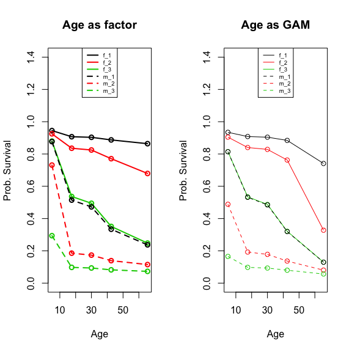

```r
par(mfrow = c(1, 2))
plot(pred_f_1$pred_age_f ~ pred_f_1$age, type = "o", lwd = 2, ylim = c(0, 1.4),
    ylab = "Prob. Survival", xlab = "Age", main = "Age as factor")
points(pred_f_2$pred_age_f ~ pred_f_2$age, type = "o", lwd = 2, col = 2)
points(pred_f_3$pred_age_f ~ pred_f_3$age, type = "o", lwd = 2, col = 3)

points(pred_m_1$pred_age_f ~ pred_m_1$age, type = "o", lwd = 2, col = 1, lty = 2)
points(pred_m_2$pred_age_f ~ pred_m_2$age, type = "o", lwd = 2, col = 2, lty = 2)
points(pred_m_3$pred_age_f ~ pred_m_3$age, type = "o", lwd = 2, col = 3, lty = 2)

legend("top", lty = c(1, 1, 1, 2, 2, 2), col = c(1:3, 1:3),
       legend = c("f_1", "f_2", "f_3", "m_1", "m_2", "m_3"),
       lwd = rep(2, 6), cex = 0.6)

plot(pred_f_1$pred_age_gam ~ pred_f_2$age, type = "o", ylim = c(0, 1.4),
    ylab = "Prob. Survival", xlab = "Age", main = "Age as GAM")
points(pred_f_2$pred_age_gam ~ pred_f_2$age, type = "o", col = 2)
points(pred_f_3$pred_age_gam ~ pred_f_3$age, type = "o", col = 3)

points(pred_m_1$pred_age_gam ~ pred_m_1$age, type = "o", col = 1, lty = 2)
points(pred_m_2$pred_age_gam ~ pred_m_2$age, type = "o", col = 2, lty = 2)
points(pred_m_3$pred_age_gam ~ pred_m_3$age, type = "o", col = 3, lty = 2)

legend("top", lty = c(1, 1, 1, 2, 2, 2), col = c(1:3, 1:3),
       legend = c("f_1", "f_2", "f_3", "m_1", "m_2", "m_3"),
       lwd = rep(1, 6), cex = 0.6)
```

## Odds-ratio

As the model is not fitted with link = logit, the odd ratio are not constant with age…

```r
p1 <- pred_f_1[pred_f_1$age == 5, "pred_age_f"]
p2 <- pred_m_3[pred_m_3$age == 5, "pred_age_f"]
(p1/(1 - p1)) / (p2/(1 - p2))
```

```
## [1] 41.30262
```

```r
p1 <- pred_f_1[pred_f_1$age == 65.5, "pred_age_f"]
p2 <- pred_m_3[pred_m_3$age == 65.5, "pred_age_f"]
(p1/(1 - p1)) / (p2/(1 - p2))
```

```
## [1] 80.77962
```

```r
p1 <- pred_f_1[pred_f_1$age == 5, "pred_age_gam"]
p2 <- pred_m_3[pred_m_3$age == 5, "pred_age_gam"]
(p1/(1 - p1)) / (p2/(1 - p2))
```

```
## [1] 71.77181
```

```r
p1 <- pred_f_1[pred_f_1$age == 65.5, "pred_age_gam"]
p2 <- pred_m_3[pred_m_3$age == 65.5, "pred_age_gam"]
(p1/(1 - p1)) / (p2/(1 - p2))
```

```
## [1] 47.88521
```

Note: the differences between the two models are at the extrems for which have few observations.

```r
with(subset(TitanicSurvival, age_f == "[0,10]"), table(passengerClass, sex))
```

```
##               sex
## passengerClass female male
##            1st      1    3
##            2nd     11   11
##            3rd     29   31
```

```r
with(subset(TitanicSurvival, age_f == "(50,81]"), table(passengerClass, sex))
```

```
##               sex
## passengerClass female male
##            1st     27   37
##            2nd      4   16
##            3rd      1   10
```

# Dataset: LM2GLMM::Challenger

### Goal

- What was the probability of O-ring failure when the space shuttle Challenger took off on the 28th of January 1986 by 31 degrees F?

# Dataset: LM2GLMM::UK

### Goal

- Try to identify the influential determinants of the smoking behaviour of children.
- Try to identify the influential determinants of bronchitis in children.
- Try to identify the influential determinants of the variable `backward`.

# Dataset: HSE98women, exercise menopause

## Goal

- Study the influences of age, body mass index and smoking status upon the probability of being menopaused
- Estimate the proportion of menopaused women in the population, depending on their age (40, 45, 50, 55, 60 yrs)

Note: here, for the sake of simplicity we simply define menopause as the lack of periods in old ages.

## Data preparation and exploration

We create the response variable:

```r
HSE98women$menopause <-  HSE98women$period == FALSE
```

We fit a first model to help us easily exploring the data used for fitting and not all data (there are many missing values in the dataset).

```r
mod_menop_logit <- glm(menopause ~ age + bmi + smoked, data = HSE98women, family = binomial())
nrow(HSE98women) ## original number of observations
```

```
## [1] 10556
```

```r
nrow(mod_menop_logit$model)  ## number of observations considered in the model
```

```
## [1] 7218
```

We compare the variables before and after filtering to see if any obvious biais is introduced by the observations we discared:

```r
summary(HSE98women[, c("menopause", "age", "bmi", "smoked")])
```

```
##  menopause            age             bmi          smoked
##  Mode :logical   Min.   : 2.00   Min.   :12.39   Mode :logical
##  FALSE:4303      1st Qu.:23.00   1st Qu.:21.11   FALSE:3959
##  TRUE :3741      Median :39.00   Median :24.38   TRUE :4735
##  NA's :2512      Mean   :40.52   Mean   :24.96   NA's :1862
##                  3rd Qu.:58.00   3rd Qu.:28.30
##                  Max.   :97.00   Max.   :54.95
##                                  NA's   :1172
```

```r
summary(mod_menop_logit$model)
```

```
##  menopause            age             bmi          smoked
##  Mode :logical   Min.   :18.00   Min.   :13.80   Mode :logical
##  FALSE:3967      1st Qu.:33.00   1st Qu.:22.79   FALSE:3214
##  TRUE :3251      Median :46.00   Median :25.55   TRUE :4004
##                  Mean   :47.38   Mean   :26.47
##                  3rd Qu.:61.00   3rd Qu.:29.30
##                  Max.   :94.00   Max.   :54.95
```

The only big discrepancy between the two datasets is that the minimal age is now 18 yrs old while the original dataset also contains children. That suggests that girls too young to have periods are not being considered, which will greatly help us to model menopause.

Let’s check the correlation between our two continuous predictor:

```r
cor.test(HSE98women$age, HSE98women$bmi)
```

```
##
##  Pearson's product-moment correlation
##
## data:  HSE98women$age and HSE98women$bmi
## t = 50.874, df = 9382, p-value < 2.2e-16
## alternative hypothesis: true correlation is not equal to 0
## 95 percent confidence interval:
##  0.4489847 0.4807042
## sample estimates:
##       cor
## 0.4649937
```

```r
cor.test(mod_menop_logit$model$age, mod_menop_logit$model$bmi)
```

```
##
##  Pearson's product-moment correlation
##
## data:  mod_menop_logit$model$age and mod_menop_logit$model$bmi
## t = 13.85, df = 7216, p-value < 2.2e-16
## alternative hypothesis: true correlation is not equal to 0
## 95 percent confidence interval:
##  0.1383667 0.1833131
## sample estimates:
##       cor
## 0.1609233
```

The correlation is not very high, especially in the dataset that is used for the fit, so multicollinearity should not be an issue.

We visualise the relationship between the predictor and the response:

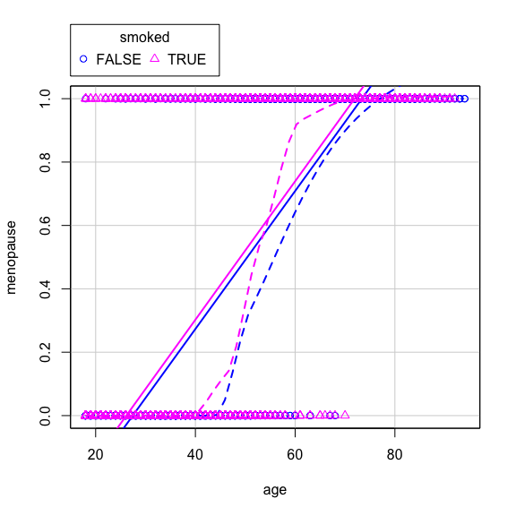

```r
library(car)
mod_menop_logit$model$smoked <- as.factor(mod_menop_logit$model$smoked) ## patch to solve bug in car 3.0
scatterplot(menopause ~ age + smoked, data = mod_menop_logit$model)
```

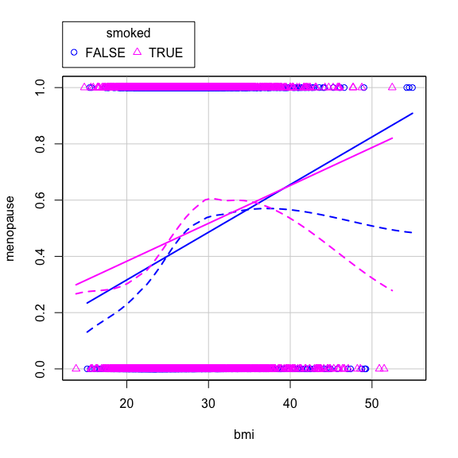

```r
scatterplot(menopause ~ bmi + smoked, data = mod_menop_logit$model)
```

There don’t seem to be any obvious interaction between the age and smoked or between BMI and smoked, so we won’t consider any. We will however consider that the effect of age may depend on the BMI because while old individuals should be menopaused no matter their BMI, we may expect that obesity play a role early on.

## Fitting the models

```r
mod_menop_logit   <- glm(menopause ~ age * bmi + smoked, data = HSE98women, family = binomial())
mod_menop_probit  <- glm(menopause ~ age * bmi + smoked, data = HSE98women, family = binomial(link = "probit"))
mod_menop_cauchit <- glm(menopause ~ age * bmi + smoked, data = HSE98women, family = binomial(link = "cauchit"))
```

Because it is very difficult to explore the shape of the relationship between the age and bmi upon the probability of being menopaused, we will also fit general additive models (GAM), which allows parameters to vary along the predictors.

```r
library(mgcv)
mod_menop_logit_gam   <- gam(menopause ~ s(age, bmi) + smoked, data = HSE98women, family = binomial())
mod_menop_probit_gam  <- gam(menopause ~ s(age, bmi) + smoked, data = HSE98women, family = binomial(link = "probit"))
mod_menop_cauchit_gam <- gam(menopause ~ s(age, bmi) + smoked, data = HSE98women, family = binomial(link = "cauchit"))
```

```r
cbind(logit = AIC(mod_menop_logit),
      probit = AIC(mod_menop_probit),
      cauchit = AIC(mod_menop_cauchit),
      logit_GAM = AIC(mod_menop_logit_gam),
      probit_GAM = AIC(mod_menop_probit_gam),
      cauchit_GAM = AIC(mod_menop_cauchit_gam)
      )
```

```
##         logit   probit  cauchit logit_GAM probit_GAM cauchit_GAM
## [1,] 3985.441 4097.282 3839.312   3720.37   3722.458     3733.11
```

The GAM logit model seems to be the best model, which will prevent us to express simply the effect of coefficients compared to a usual GLM. That’s too bad but as the model is much better, we will go for it.

## Tests

We are going to test for the effect of the interaction by Likelihood ratio test:

```r
mod_menop_logit_gam_no_int <- gam(menopause ~ s(age) + s(bmi) + smoked, data = HSE98women, family = binomial())
LR <- -2 * (logLik(mod_menop_logit_gam_no_int)[[1]] - logLik(mod_menop_logit_gam)[[1]])
DF <- (mod_menop_logit_gam$df.null - mod_menop_logit_gam$df.residual) - (mod_menop_logit_gam_no_int$df.null - mod_menop_logit_gam_no_int$df.residual)
(PV <- 1 - pchisq(LR, DF))
```

```
## [1] 0.175853
```

The interaction between age and BMI is not significant (LRT, LR = `4.5`, df = `2.69`, p-value = `0.18`).

Let’s now test the effect of BMI by Likelihood ratio test:

```r
mod_menop_logit_gam_no_bmi <- gam(menopause ~ s(age) + smoked, data = HSE98women, family = binomial())
LR <- -2 * (logLik(mod_menop_logit_gam_no_bmi)[[1]] - logLik(mod_menop_logit_gam)[[1]])
DF <- (mod_menop_logit_gam$df.null - mod_menop_logit_gam$df.residual) - (mod_menop_logit_gam_no_bmi$df.null - mod_menop_logit_gam_no_bmi$df.residual)
(PV <- 1 - pchisq(LR, DF))
```

```
## [1] 0
```

The effect of BMI is strongly significant (LRT, LR = `732.7`, df = `4.23`, p-value < 0.001).

Note that models with GAM have non integer degrees of freedom. This is normal.

Let’s now test the effect of age by Likelihood ratio test:

```r
mod_menop_logit_gam_no_age <- gam(menopause ~ s(bmi) + smoked, data = HSE98women, family = binomial())
LR <- -2 * (logLik(mod_menop_logit_gam_no_age)[[1]] - logLik(mod_menop_logit_gam)[[1]])
DF <- (mod_menop_logit_gam$df.null - mod_menop_logit_gam$df.residual) - (mod_menop_logit_gam_no_age$df.null - mod_menop_logit_gam_no_age$df.residual)
(PV <- 1 - pchisq(LR, DF))
```

```
## [1] 0
```

The effect of age is strongly significant (LRT, LR = `5900.1`, df = `5.42`, p-value < 0.001).

Let’s now test the effect of smoking by Likelihood ratio test:

```r
mod_menop_logit_gam_never_smoked <- gam(menopause ~ s(age, bmi), data = HSE98women, family = binomial())
LR <- -2 * (logLik(mod_menop_logit_gam_never_smoked)[[1]] - logLik(mod_menop_logit_gam)[[1]])
DF <- (mod_menop_logit_gam$df.null - mod_menop_logit_gam$df.residual) - (mod_menop_logit_gam_never_smoked$df.null - mod_menop_logit_gam_never_smoked$df.residual)
(PV <- 1 - pchisq(LR, DF))
```

```
## [1] 0.0001646144
```

The effect of have smooked is also significant (LRT, LR = `14.5`, df = `1.09`, p-value < 0.001).

## Predictions

Let’s first explore the model output with the pacakge `visreg`, which also works on GAM models:

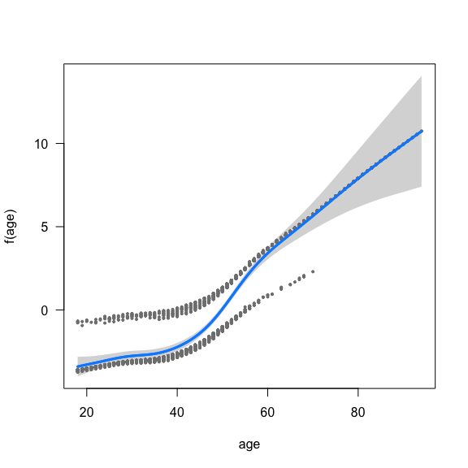

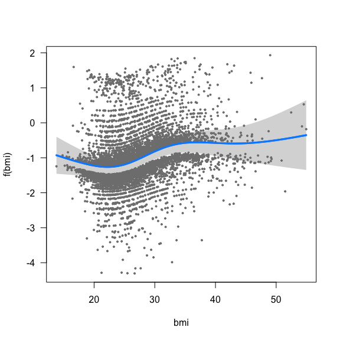

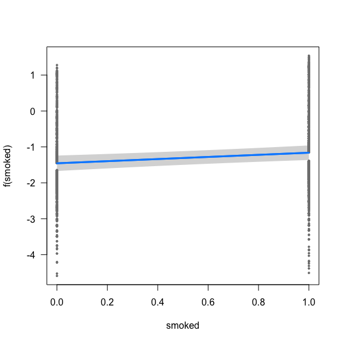

```r
library(visreg)
visreg(mod_menop_logit_gam)
```

These plots show the patterns identified by the smoothing parameters in the GAM: the effect of age seems to change after 40 yrs and the effect of BMI seem to be changing between 23 and 32 yrs. It is difficult to account for such threshold effects by polynoms, so we will have to stick to GAM here…

Le’t us do the same plots on the scale of the response variable:

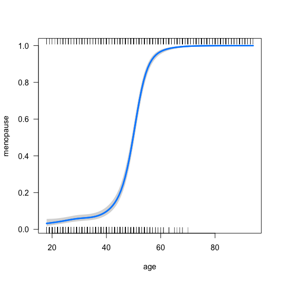

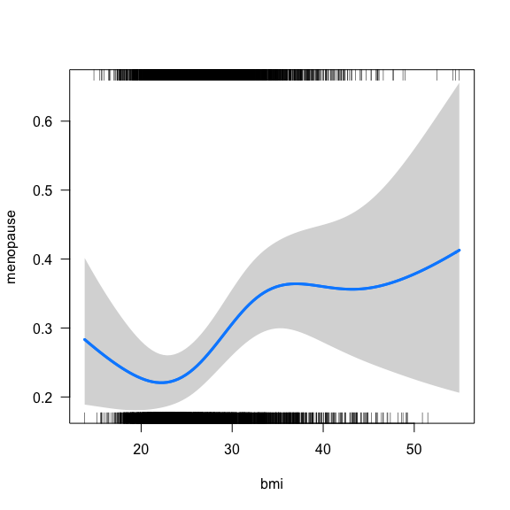

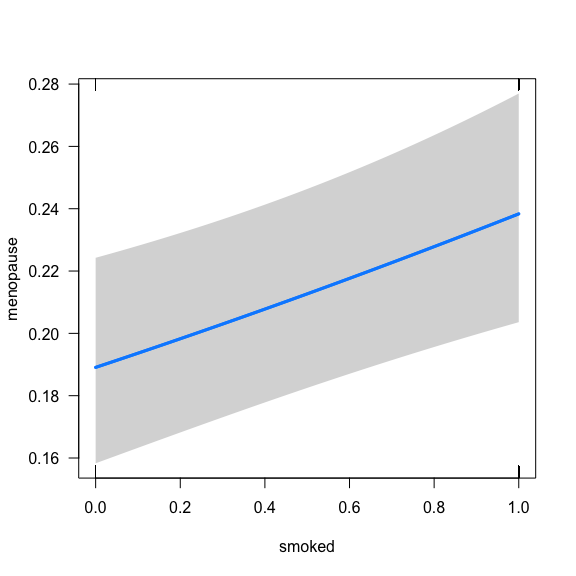

```r
visreg(mod_menop_logit_gam, scale = "response")
```

We will now plot the predictions for the model with the logit link, the model with the cauchit link and the model with the GAM model with the logit link to explore their differences. We will predict the influence of age and consider the median BMI and smokers.

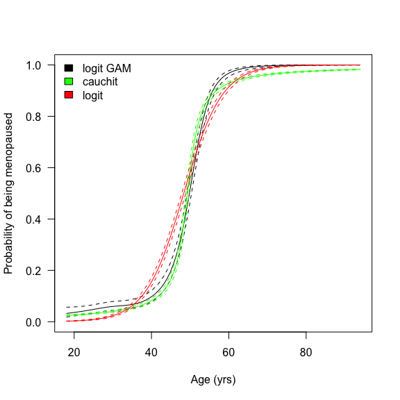

```r
age.for.pred <- seq(min(mod_menop_cauchit_gam$model$age), max(mod_menop_cauchit_gam$model$age), length = 100)
data.for.pred <- expand.grid(
  age = age.for.pred,
  bmi = median(mod_menop_cauchit_gam$model$bmi),
  smoked = TRUE
  )

  gam.p <- predict(mod_menop_logit_gam, newdata = data.for.pred, se.fit = TRUE)
gam.upr <- binomial(link = "logit")$linkinv(gam.p$fit + qnorm(0.975) * gam.p$se.fit)
gam.lwr <- binomial(link = "logit")$linkinv(gam.p$fit + qnorm(0.025) * gam.p$se.fit)
gam.fit <- binomial(link = "logit")$linkinv(gam.p$fit)

cauchit.p <- predict(mod_menop_cauchit, newdata = data.for.pred, se.fit = TRUE)
cauchit.upr <- binomial(link = "cauchit")$linkinv(cauchit.p$fit + qnorm(0.975) * cauchit.p$se.fit)
cauchit.lwr <- binomial(link = "cauchit")$linkinv(cauchit.p$fit + qnorm(0.025) * cauchit.p$se.fit)
cauchit.fit <- binomial(link = "cauchit")$linkinv(cauchit.p$fit)

logit.p <- predict(mod_menop_logit, newdata = data.for.pred, se.fit = TRUE)
logit.upr <- binomial(link = "logit")$linkinv(logit.p$fit + qnorm(0.975) * logit.p$se.fit)
logit.lwr <- binomial(link = "logit")$linkinv(logit.p$fit + qnorm(0.025) * logit.p$se.fit)
logit.fit <- binomial(link = "logit")$linkinv(logit.p$fit)

plot(gam.fit ~ age.for.pred, type = "l", las = 1, ylab = "Probability of being menopaused", xlab = "Age (yrs)", ylim = c(0, 1))
points(gam.upr ~ age.for.pred, type = "l", lty = 2)
points(gam.lwr ~ age.for.pred, type = "l", lty = 2)

points(cauchit.fit ~ age.for.pred, type = "l", lty = 1, col = "green")
points(cauchit.upr ~ age.for.pred, type = "l", lty = 2, col = "green")
points(cauchit.lwr ~ age.for.pred, type = "l", lty = 2, col = "green")

points(logit.fit ~ age.for.pred, type = "l", lty = 1, col = "red")
points(logit.upr ~ age.for.pred, type = "l", lty = 2, col = "red")
points(logit.lwr ~ age.for.pred, type = "l", lty = 2, col = "red")

legend("topleft", fill = c("black", "green", "red"), legend = c("logit GAM", "cauchit", "logit"), bty = "n")
```

Selecting the best model, let’s now look at the effect of BMI, still using smokers:

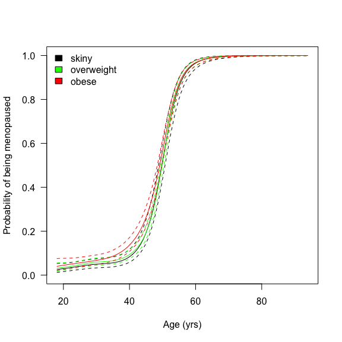

```r
data.for.pred <- expand.grid(
  age = age.for.pred,
  bmi = c(18.5, 25, 30),
  smoked = TRUE
  )

gam.skiny.p <- predict(mod_menop_logit_gam, newdata = subset(data.for.pred, bmi == 18.5), se.fit = TRUE)
gam.skiny.upr <- binomial(link = "logit")$linkinv(gam.skiny.p$fit + qnorm(0.975) * gam.skiny.p$se.fit)
gam.skiny.lwr <- binomial(link = "logit")$linkinv(gam.skiny.p$fit + qnorm(0.025) * gam.skiny.p$se.fit)
gam.skiny.fit <- binomial(link = "logit")$linkinv(gam.skiny.p$fit)

gam.overweight.p <- predict(mod_menop_logit_gam, newdata = subset(data.for.pred, bmi == 25), se.fit = TRUE)
gam.overweight.upr <- binomial(link = "logit")$linkinv(gam.overweight.p$fit + qnorm(0.975) * gam.overweight.p$se.fit)
gam.overweight.lwr <- binomial(link = "logit")$linkinv(gam.overweight.p$fit + qnorm(0.025) * gam.overweight.p$se.fit)
gam.overweight.fit <- binomial(link = "logit")$linkinv(gam.overweight.p$fit)

gam.obese.p <- predict(mod_menop_logit_gam, newdata = subset(data.for.pred, bmi == 30), se.fit = TRUE)
gam.obese.upr <- binomial(link = "logit")$linkinv(gam.obese.p$fit + qnorm(0.975) * gam.obese.p$se.fit)
gam.obese.lwr <- binomial(link = "logit")$linkinv(gam.obese.p$fit + qnorm(0.025) * gam.obese.p$se.fit)
gam.obese.fit <- binomial(link = "logit")$linkinv(gam.obese.p$fit)

plot(gam.skiny.fit ~ age.for.pred, type = "l", las = 1, ylab = "Probability of being menopaused", xlab = "Age (yrs)", ylim = c(0, 1))
points(gam.skiny.upr ~ age.for.pred, type = "l", lty = 2)
points(gam.skiny.lwr ~ age.for.pred, type = "l", lty = 2)

points(gam.overweight.fit ~ age.for.pred, type = "l", lty = 1, col = "green")
points(gam.overweight.upr ~ age.for.pred, type = "l", lty = 2, col = "green")
points(gam.overweight.lwr ~ age.for.pred, type = "l", lty = 2, col = "green")

points(gam.obese.fit ~ age.for.pred, type = "l", lty = 1, col = "red")
points(gam.obese.upr ~ age.for.pred, type = "l", lty = 2, col = "red")
points(gam.obese.lwr ~ age.for.pred, type = "l", lty = 2, col = "red")

legend("topleft", fill = c("black", "green", "red"), legend = c("skiny", "overweight", "obese"), bty = "n")
```

We can see on this plot that obesity seems to accelerate the onset of menopause, but it does not seem to make any difference later on.

We will now predict the proportion of women in menopause at 40, 45, 50, 55 and 60 yrs. To illustrate the effect ofthe BMI will will perform prediction for a BMI of 21.75 (middle of normal BMI range according to WHO) and 30 (lower limit for obesity) Kg/(m^2). Again, we will perform the predictions considering smoker since we have data for this category. We will also compute the confidence intervals (prediction intervals make little sense in the context of the prediction of proportion…).

```r
data.for.pred <- expand.grid(
  age = c(40, 45, 50, 55, 60),
  bmi = c(21.75, 30),
  smoked = TRUE
  )
pred_normal <- predict(mod_menop_logit_gam, newdata = subset(data.for.pred, bmi == 21.75), se.fit = TRUE)
tab_normal <- cbind(
  predict = plogis(pred_normal$fit),
  lwr.CI = plogis(pred_normal$fit + qnorm(0.025)*pred_normal$se.fit),
  upr.CI = plogis(pred_normal$fit + qnorm(0.975)*pred_normal$se.fit)
)
rownames(tab_normal) <- c(40, 45, 50, 55, 60)
round(tab_normal, 2)
```

```
##    predict lwr.CI upr.CI
## 40    0.08   0.06   0.10
## 45    0.18   0.15   0.22
## 50    0.51   0.45   0.56
## 55    0.87   0.83   0.90
## 60    0.97   0.95   0.98
```

This gives the information for individuals for normal BMI. Let’s now look at the corresponding proportion for the obeses:

```r
pred_obses <- predict(mod_menop_logit_gam, newdata = subset(data.for.pred, bmi == 30), se.fit = TRUE)
tab_obses <- cbind(
  predict = plogis(pred_obses$fit),
  lwr.CI = plogis(pred_obses$fit + qnorm(0.025)*pred_obses$se.fit),
  upr.CI = plogis(pred_obses$fit + qnorm(0.975)*pred_obses$se.fit)
)
rownames(tab_obses) <- c(40, 45, 50, 55, 60)
round(tab_obses, 2)
```

```
##    predict lwr.CI upr.CI
## 40    0.14   0.11   0.17
## 45    0.26   0.22   0.31
## 50    0.57   0.51   0.62
## 55    0.87   0.84   0.90
## 60    0.97   0.95   0.98
```

These tables confirm our expectation concerning the influenc of BMI upon the onset of menopause.

For the sake of comparion, let’s compare the first table to what we would have predicted using the cauchit model or the logit GLM model:

```r
data.for.pred <- expand.grid(age = c(40, 45, 50, 55, 60), bmi = 21.75, smoked = TRUE)
pred_GAM <- predict(mod_menop_logit_gam, newdata = subset(data.for.pred, bmi == 21.75), se.fit = TRUE)
pred_logit <- predict(mod_menop_logit, newdata = subset(data.for.pred, bmi == 21.75), se.fit = TRUE)
pred_cauchit <- predict(mod_menop_cauchit, newdata = subset(data.for.pred, bmi == 21.75), se.fit = TRUE)
tab <- cbind(
  logit_GAM = plogis(pred_GAM$fit),
  logit_GLM = plogis(pred_logit$fit),
  cauchit_GLM = binomial(link = "cauchit")$linkinv(pred_cauchit$fit)
)
rownames(tab) <- c(40, 45, 50, 55, 60)
round(tab, 2)
```

```
##    logit_GAM logit_GLM cauchit_GLM
## 40      0.08      0.14        0.07
## 45      0.18      0.32        0.15
## 50      0.51      0.56        0.57
## 55      0.87      0.78        0.88
## 60      0.97      0.91        0.93
```

Let’s look at the same proportion in the raw data. We cannot be as strict otherwise we won’t get much individuals, so let’s enlarge a bit the selection and see that we get a few hundred individuals at least:

```r
tab <- with(HSE98women,
     rbind(sum(age >= 39 & age <= 41 & bmi > 18.5 & bmi < 25, na.rm = TRUE),
           sum(age >= 44 & age <= 46 & bmi > 18.5 & bmi < 25, na.rm = TRUE),
           sum(age >= 49 & age <= 51 & bmi > 18.5 & bmi < 25, na.rm = TRUE),
           sum(age >= 54 & age <= 56 & bmi > 18.5 & bmi < 25, na.rm = TRUE),
           sum(age >= 59 & age <= 61 & bmi > 18.5 & bmi < 25, na.rm = TRUE)
           )
)
rownames(tab) <- c(40, 45, 50, 55, 60)
tab
```

```
##    [,1]
## 40  199
## 45  160
## 50  172
## 55  132
## 60   97
```

That seems a good selection process (+/- 1 year and the whole WHO normal BMI category), so let’s check the proportion of menopaused individuals in each of these categories (keeping both smokers and non smokers as the effect is rather small, see later):

```r
tab <- with(HSE98women,
     rbind(
       mean(menopause[age >= 39 & age <= 41 & bmi > 18.5 & bmi < 25], na.rm = TRUE),
       mean(menopause[age >= 44 & age <= 46 & bmi > 18.5 & bmi < 25], na.rm = TRUE),
       mean(menopause[age >= 49 & age <= 51 & bmi > 18.5 & bmi < 25], na.rm = TRUE),
       mean(menopause[age >= 54 & age <= 56 & bmi > 18.5 & bmi < 25], na.rm = TRUE),
       mean(menopause[age >= 59 & age <= 61 & bmi > 18.5 & bmi < 25], na.rm = TRUE)
     )
)
rownames(tab) <- c(40, 45, 50, 55, 60)
round(tab, 2)
```

```
##    [,1]
## 40 0.08
## 45 0.12
## 50 0.52
## 55 0.86
## 60 0.98
```

These results are roughly consistent with the predictions from the GAM model. It confirms that the GLM logit and cauchit are underestimating the prevalence of menopause at old age. All models however may overestimate the prevalence of menaupose at young age. Depending on the goal of the study, other link functions, not implemented in R base, could be tried but it is quite advanced so we won’t do that.

We can now turn to the exploration of the smoking effect by comparing predictions between smokers and non smokers at median BMI:

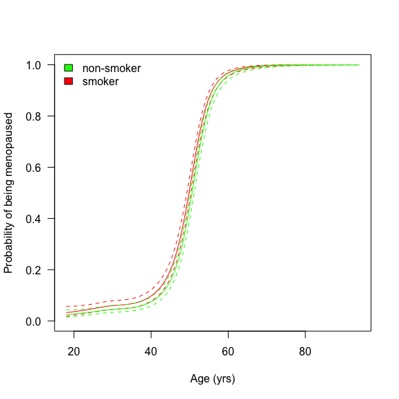

```r
data.for.pred.nosmoke <- expand.grid(
  age = age.for.pred,
  bmi = median(mod_menop_cauchit_gam$model$bmi),
  smoked = FALSE
  )

gam.p.nosmoke <- predict(mod_menop_logit_gam, newdata = data.for.pred.nosmoke, se.fit = TRUE)
gam.upr.nosmoke <- binomial(link = "logit")$linkinv(gam.p.nosmoke$fit + qnorm(0.975) * gam.p.nosmoke$se.fit)
gam.lwr.nosmoke <- binomial(link = "logit")$linkinv(gam.p.nosmoke$fit + qnorm(0.025) * gam.p.nosmoke$se.fit)
gam.fit.nosmoke <- binomial(link = "logit")$linkinv(gam.p.nosmoke$fit)


plot(gam.fit ~ age.for.pred, type = "l", las = 1, ylab = "Probability of being menopaused", xlab = "Age (yrs)", ylim = c(0, 1), col = "red")
points(gam.upr ~ age.for.pred, type = "l", lty = 2, col = "red")
points(gam.lwr ~ age.for.pred, type = "l", lty = 2, col = "red")

points(gam.fit.nosmoke ~ age.for.pred, type = "l", col = "green")
points(gam.upr.nosmoke ~ age.for.pred, type = "l", lty = 2, col = "green")
points(gam.lwr.nosmoke ~ age.for.pred, type = "l", lty = 2, col = "green")

legend("topleft", fill = c("green", "red"), legend = c("non-smoker", "smoker"), bty = "n")
```

# Dataset: MASS::mammals

## Goal

- What is the allometric exponent for the growth of brain size with body mass?
- Does this exponent agree with the usual expectation of 2/3?
- How large do we expect a 1kg animal to be?
- Rank organisms by relative brain size (i.e. controlled for body size)
- Repeat the analysis with the dataset `MASS::Animals`